# Set scores

singscore (Foroutan et al. 2018) gives every biopsy one score per gene set. Within a biopsy, it ranks all genes by abundance and averages the ranks of the set’s members. A set whose members sit high in that biopsy scores high. The score depends only on ranks inside one biopsy, so it does not move when other biopsies are added or removed. This step computes scores and describes them; it tests nothing.

## Packages

singscore is called with `::` where used.

```r
library(here)
library(dplyr)
library(ggplot2)
source(here("00_Setup", "Shared_functions", "workbooks.R"))
inputs <- c(
  gene_sets = "01_Processing/04_Gene_Sets/c_data/gene_sets.rds",
  proteins = "01_Processing/03_Blood_Correction/c_data/blood_correction.rds"
)
paths <- vapply(inputs, here, character(1))
stopifnot(file.exists(paths))
```

Ranking needs every protein in every biopsy and cannot carry a covariate, so the input is limpa’s complete matrix with each protein’s blood slope removed from its observed values (`blood_correction.rds`, from `03_Blood_Correction`). Values limpa estimated from the detection curve are unchanged there.

```r
gs <- readRDS(paths[["gene_sets"]])
proteins <- readRDS(paths[["proteins"]])
targets <- proteins$targets
c(sets = length(gs$sets), proteins = nrow(proteins), biopsies = ncol(proteins))
```

```
    sets proteins biopsies
    1422     2059       48
```

Sets are keyed on gene symbols, so the matrix rows switch from accessions to the representative gene chosen in `04_Gene_Sets`.

```r
gene_map <- filter(gs$protein_map, selected)
stopifnot(all(gene_map$uniprot_id %in% rownames(proteins)), !anyDuplicated(gene_map$gene))
gene_matrix <- proteins$E[gene_map$uniprot_id, ]
rownames(gene_matrix) <- gene_map$gene
dim(gene_matrix)
```

```
[1] 2058   48
```

```r
round(gene_matrix[1:3, 1:3], 2)
```

```
       S03_T1 S03_T2 S03_T3
GATD3B  20.97  21.47  20.96
ESYT2   15.77  15.77  17.01
ILVBL   14.78  16.54  16.27
```

## Scores

`rankGenes()` ranks genes within each biopsy. `multiScore()` scores every set in one pass and also returns each set’s dispersion: the spread (median absolute deviation) of its members’ ranks within a biopsy. Low dispersion means the members sit together; high means they scatter. By default singscore centres the score so that 0 means the members’ average rank equals the biopsy’s middle rank.

```r
ranks <- singscore::rankGenes(gene_matrix)
scored <- singscore::multiScore(ranks, upSetColc = gs$sets)
scores <- scored$Scores
stopifnot(
  identical(rownames(scores), names(gs$sets)),
  identical(colnames(scores), targets$sample_id)
)
dim(scores)
```

```
[1] 1422   48
```

```r
round(scores[1:3, 1:4], 3)
```

```
                                      S03_T1 S03_T2 S03_T3 S04_T1
Hallmark|HALLMARK_ADIPOGENESIS         0.135  0.149  0.112  0.139
Hallmark|HALLMARK_ALLOGRAFT_REJECTION -0.044 -0.015  0.006 -0.004
Hallmark|HALLMARK_ANDROGEN_RESPONSE   -0.037 -0.004  0.014  0.053
```

Spread across sets within a biopsy reflects which genes each set holds. Spread across biopsies within a set is what later comparisons use. Both are recorded.

```r
score_summary <- tibble(
  n_sets = nrow(scores), n_samples = ncol(scores),
  min = round(min(scores), 4), max = round(max(scores), 4),
  mean = round(mean(scores), 4),
  mean_sd_across_sets = round(mean(apply(scores, 2, sd)), 4),
  mean_sd_across_samples = round(mean(apply(scores, 1, sd)), 4)
)
score_summary
```

```
# A tibble: 1 × 7
  n_sets n_samples    min   max   mean mean_sd_across_sets
   <int>     <int>  <dbl> <dbl>  <dbl>               <dbl>
1   1422        48 -0.404 0.418 0.0259              0.0975
# ℹ 1 more variable: mean_sd_across_samples <dbl>
```

```r
set_spread <- gs$set_catalog |>
  filter(qualifies) |>
  transmute(set_id, collection) |>
  mutate(
    score = rowMeans(scores[set_id, ]),
    dispersion = rowMeans(scored$Dispersions[set_id, ])
  )
collection_spread <- set_spread |>
  summarise(
    n_sets = n(), median_score = round(median(score), 4),
    median_dispersion = round(median(dispersion), 1), .by = collection
  )
collection_spread
```

```
# A tibble: 5 × 4
  collection  n_sets median_score median_dispersion
  <chr>        <int>        <dbl>             <dbl>
1 Hallmark        35       0.0443              674.
2 Reactome       321       0.0708              544.
3 KEGG_Legacy     55       0.0472              594
4 GOBP           953      -0.0039              661.
5 GO_Slim         58      -0.0006              682.
```

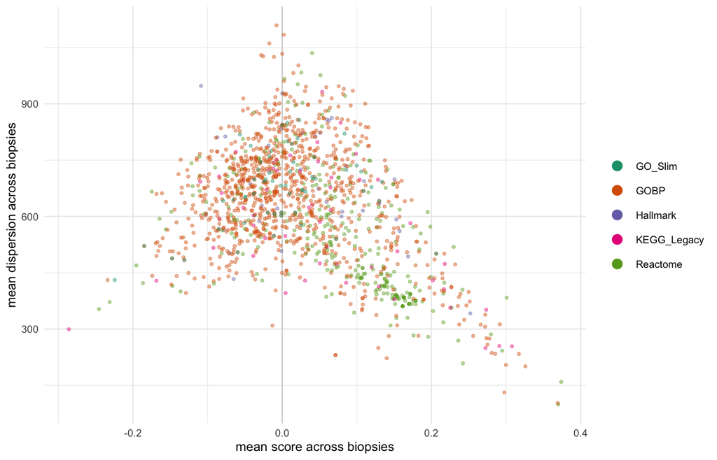

Figure 1: Each set’s mean score against its mean dispersion, averaged over biopsies.

```r
ggplot(set_spread, aes(score, dispersion, colour = collection)) +
  geom_vline(xintercept = 0, linewidth = 0.3, colour = "grey80") +
  geom_point(alpha = 0.4, size = 0.8) +
  scale_colour_brewer(palette = "Dark2", name = NULL) +
  guides(colour = guide_legend(override.aes = list(size = 3, alpha = 1))) +
  labs(x = "mean score across biopsies", y = "mean dispersion across biopsies") +
  theme_minimal(base_size = 9)
```

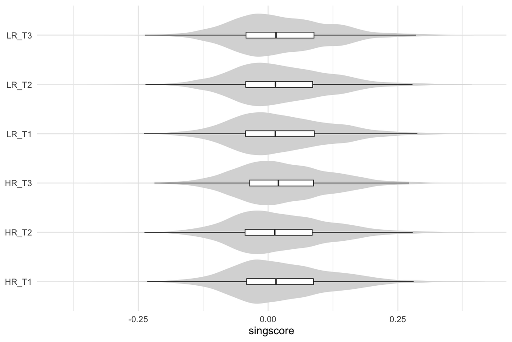

Figure 2: Every set’s score in every biopsy, pooled within each group-by-time cell.

```r
tibble(group_time = rep(targets$group_time, each = nrow(scores)), score = as.vector(scores)) |>
  ggplot(aes(score, group_time)) +
  geom_violin(fill = "grey85", colour = NA) +
  geom_boxplot(width = 0.12, outlier.shape = NA, linewidth = 0.3) +
  labs(x = "singscore", y = NULL) +
  theme_minimal(base_size = 9)
```